# Microbiome Analysis

# We’re going to set up all the data and put it into a phyloseq object that easy to work with

```r
library(phyloseq)
library(ape)
library(phytools)
```

```r
source("~/Lab/microbiome2/scripts/getTables.R")
mapping <- getMapping()
table <- getOtuTable()
tax <- read.csv("~/Lab/16S/dada2/taxa_table.txt", row.names=1, sep="")
tree = read.tree("~/Lab/16S/dada2/tree_midpointRoot.tre")

metadata <- sample_data(data.frame( SampleID = mapping$SampleID,
                                    pair=mapping$Pair,
                                    classifier=mapping$classifier,
                                    age=mapping$age_month_ok,
                                    batch=factor(mapping$batch),
                                    treatment= factor(mapping$Treatment, levels = c("Aut", "Control"))))
rownames(metadata) <- mapping$SampleID

ps <- phyloseq(otu_table(table, taxa_are_rows=T),
               sample_data(metadata),
               tax_table(as.matrix(tax)),
               phy_tree(tree))

ps_aut <- subset_samples(ps, treatment == "Aut")
ps_control <- subset_samples(ps, treatment == "Control")
```

# Delta Between Classes

### Weighted Unifrac Distances between Aut-Aut samples and Control-Control samples

Note that Unifrac distance goes from 0 to 1. The resulting figure should be interpreted with this in mind.

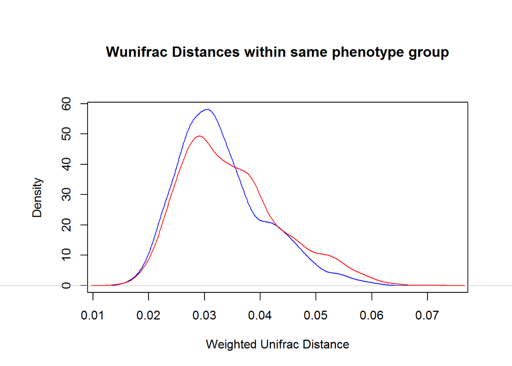

```r
distance_measure = "wunifrac"
dists_aut <- phyloseq::distance(ps_aut, method = distance_measure)
dists_control <- phyloseq::distance(ps_control, method = distance_measure)

par(xpd=TRUE, mar = c(5,6,7,3))
plot(density(as.vector(dists_control)), col = "blue",
     main= "Wunifrac Distances within same phenotype group", xlab = "Weighted Unifrac Distance")
lines(density(as.vector(dists_aut)), col = "red")
```

```r
pvalue <- ks.test(as.vector(dists_control), as.vector(dists_aut))$p.value
print(pvalue)
```

```
## [1] 1.097857e-07
```

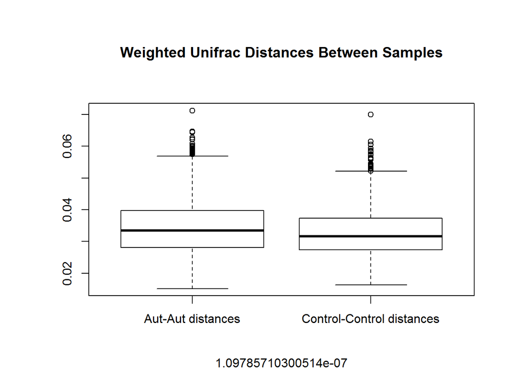

```r
boxplot(dists_aut, dists_control, names=c("Aut-Aut distances", "Control-Control distances"),
        main = "Weighted Unifrac Distances Between Samples",
        sub=paste(ks.test(dists_aut, dists_control)$p.value)
        )
```

### Unifrac Distances between Aut-Aut samples and Control-Control samples

This measure is a prescence/absence metric. It is not recommended to use along with css normalization (which is used on this dataset). Therefore, we should not use this in our analysis

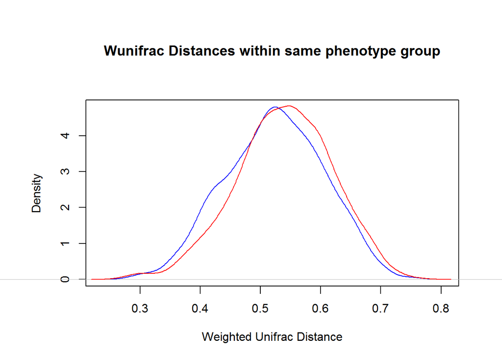

```r
distance_measure = "unifrac"
dists_aut <- phyloseq::distance(ps_aut, method = distance_measure)
dists_control <- phyloseq::distance(ps_control, method = distance_measure)

par(xpd=TRUE, mar = c(5,6,7,3))
plot(density(as.vector(dists_control)), col = "blue",
     main= "Wunifrac Distances within same phenotype group", xlab = "Weighted Unifrac Distance")
lines(density(as.vector(dists_aut)), col = "red")
```

```r
pvalue <- ks.test(as.vector(dists_control), as.vector(dists_aut))$p.value
print(pvalue)
```

```
## [1] 8.416307e-06
```

### Weighted Unifrac Distances between Aut-Aut samples and Control-Control samples with data from qiime otu picking (Instead of dada2)

Originally, we processed all data using dada2 for error cleaning and qiime for otu picking. For completeness, the distance graphs using this dataset are presented

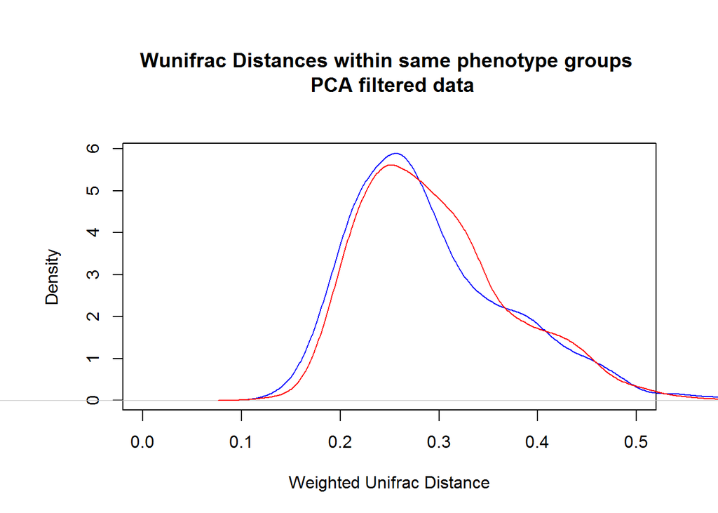

```r
ps_qiime <- readRDS("~/Lab/16S/otuTables/open_oct/ps_qiime.rds")
distance_measure = "wunifrac"
ps_aut_qiime <- subset_samples(ps_qiime, treatment == "Aut")
ps_control_qiime <- subset_samples(ps_qiime, treatment == "Control")
dists_aut_qiime <- phyloseq::distance(ps_aut_qiime, method = distance_measure)
dists_control_qiime <- phyloseq::distance(ps_control_qiime, method = distance_measure)
dists_qiime <-as.matrix(phyloseq::distance(ps_qiime, method = distance_measure))

par(xpd=TRUE, mar = c(5,6,7,3))
plot(density(as.vector(dists_control_qiime)), col = "blue",
     main= "Wunifrac Distances within same phenotype groups \n PCA filtered data", xlab = "Weighted Unifrac Distance",
     xlim=c(0, 0.5))
lines(density(as.vector(dists_aut_qiime)), col = "red")
```

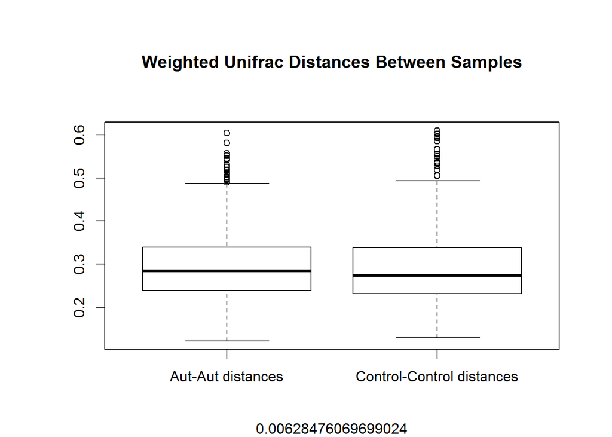

```r
boxplot(dists_aut_qiime, dists_control_qiime, names=c("Aut-Aut distances", "Control-Control distances"),
        main = "Weighted Unifrac Distances Between Samples",
        sub=paste(ks.test(dists_aut_qiime, dists_control_qiime)$p.value)
        )
```

# Machine Learning

### Functino to return Training / Testing Sets

```r
#The weird deconstruction and re-construction is because phyloseq objects completely misbehave when used within functions
getTrainTestSet <- function(ps, train_size){
  sampleData <- sample_data(ps)
  otuTable <- otu_table(ps)
  otuTable <- t(otuTable)
  taxTable <- tax_table(ps)
  tree <- phy_tree(ps)

  pairs <- sort(sampleData$pair)
  pairIds <- sort(unique(sampleData$pair))
  pairIds <- sort(pairIds[table(pairs) == 2])

  train_pairs <- sort(sample(pairIds, train_size, replace=F))
  test_pairs <- sort(pairIds[!(pairIds %in% train_pairs)])


  sampleData_train <- sampleData[sampleData$pair %in% train_pairs,]
  otuTable_train <- otuTable[sampleData$pair %in% train_pairs,]
  sampleData_test <- sampleData[sampleData$pair %in% test_pairs,]
  otuTable_test <- otuTable[sampleData$pair %in% test_pairs, ]

  ps_train <- phyloseq(otu_table(otuTable_train),
                       sample_data(sampleData_train),
                       tax_table(taxTable),
                       phy_tree(tree))


  ps_test <- phyloseq(otu_table(otuTable_test),
                      sample_data(sampleData_test),
                      tax_table(taxTable),
                      phy_tree(tree))


  return(list(ps_train, ps_test))
}
```

### Introduce some function to get otus with high mutual information

```r
library(entropy)

getMI <- function(otuVector, mapping){
  y <- matrix(c(0,0,0,0), nrow=2)
  #Create confustion matrix
  #(1,1) = no Aut, no otu =
  y[1,1] <- sum(mapping$Treatment == "Control" & otuVector == 0)
  #(1,2) = no Aut, otu
  y[1,2] <- sum(mapping$Treatment == "Control" & otuVector > 0)
  #(2,1) = Aut, not otu
  y[2,1] <- sum(mapping$Treatment == "Aut" & otuVector == 0)
  #(2,2) = Aut, otu
  y[2,2] <- sum(mapping$Treatment == "Aut" & otuVector > 0)

  return(mi.empirical(y))
}

getOtusMICutoff <- function(table, mapping, cutoff){
  otu_MI <- apply(table, 2, getMI, mapping)
  return(names(otu_MI[otu_MI > cutoff]))
}
```

## Function to perform leave 2 out validation, where we train a new NB classifier using the MI cutoff provided for every l2o train/test set. Return the average train/test error for that cutoff

```r
trainParameterNaiveBayes <- function(cutoff, ps_train){
  sampleData <- sample_data(ps_train)
  otuTable <- otu_table(ps_train)


  nsamples <- nrow(otuTable)
  testObjs <- list()
  trainObjs <- list()

  test_objs <- lapply(seq(1,nrow(otuTable)-1, by=2), function(i) return(list(otuTable[c(i, i+1),], sampleData[c(i, i+1),])))
  train_objs <- lapply(seq(1,nrow(otuTable)-1, by = 2), function(i) return(list(otuTable[-c(i, i+1),], sampleData[-c(i, i+1),])))

  models <- lapply(train_objs, trainNaiveBayes, cutoff=cutoff)
  train_error <- sapply(models, function(m) return(m$trainError))
  train_error <- mean(train_error)
  test_predictions <- mapply(function(m, test_obj) return(predict(m, test_obj[[1]])), models, test_objs)
  test_actual <- sapply(test_objs, function(test_obj) return(test_obj[[2]]$treatment))
  test_error <- sum(test_predictions != test_actual) / length(test_actual)

  return(list(train_error, test_error))
}
```

### Naive Bayes Classifier

```r
library(e1071)

trainNaiveBayes <- function(train_obj, cutoff){
  trainTable <- train_obj[[1]]
  sampleData <- train_obj[[2]]

  #Get otus with very high mutual information with autism
  imp_otus <- getOtusMICutoff(trainTable, mapping, cutoff)


  #Get only high MI otus
  trainTable_reduced <- trainTable[,colnames(trainTable) %in% imp_otus ]

  # add a case sample and control sample, each with laplaceConstant
  laplaceConstant = 2
  trainTable_reduced_laplace <- rbind(trainTable_reduced, rep(laplaceConstant,ncol(trainTable_reduced)), rep(laplaceConstant, ncol(trainTable_reduced)))
  treatments <- c(as.character(sampleData$treatment), "Aut", "Control")

  data = data.frame(cbind(trainTable_reduced_laplace,  treatments))
  m <- naiveBayes(trainTable_reduced_laplace, as.factor(treatments))
  pred_train <- predict(m, trainTable_reduced)

  m$trainError = sum(pred_train != sampleData$treatment) /length(sampleData$treatment)

  return(m)
}
```

### run if you want a graph showing training/ testing error on different MI cutoffs

```
## [1] 0.5
## [1] 0.275
```

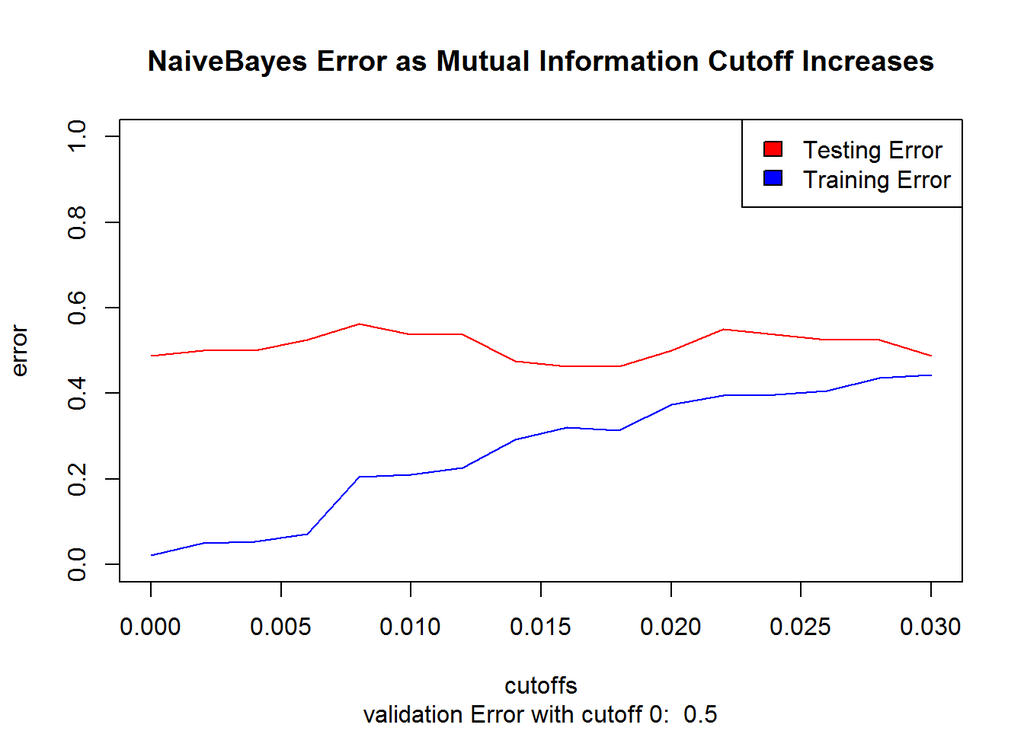

```r
errorsbyCutoff <- function(){
  temp <- getTrainTestSet(ps, 40)
  ps_train <- temp[[1]]
  ps_test <- temp[[2]]

  source("~/Lab/16S/scripts/mutualInformation.R")
  #find a cutoff that makes sense
  cutoffs <- seq(0, 0.03, by = .002)
  errors <- lapply(cutoffs, trainParameterNaiveBayes, ps_train)
  training_errors <-  unlist(errors)[rep(c(TRUE, FALSE), length(errors))]
  testing_errors <- unlist(errors)[rep(c(FALSE,TRUE), length(errors))]
  cutoff = cutoffs[testing_errors == min(testing_errors)]

  #train model on entire train set
  train_obj <- list(otu_table(ps_train), sample_data(ps_train))
  m <- trainNaiveBayes(train_obj, cutoff=cutoff)
  p <- predict(m, otu_table(ps_test))
  actual <- sample_data(ps_test)$treatment
  error_validation <- sum(actual != p) / length(p)
  print(error_validation)

  p_train <- predict(m, otu_table(ps_train))
  actual_train <- sample_data(ps_train)$treatment
  error_train <- sum(actual_train != p_train) / length(p_train)
  print(error_train)


  plot(cutoffs, testing_errors, type ='l', col="red", ylim = c(0,1), ylab="error",
       main="NaiveBayes Error as Mutual Information Cutoff Increases", sub=paste("validation Error with cutoff 0: ", error_validation))
  lines(cutoffs, training_errors, col = "blue")
  legend("topright", c("Testing Error", "Training Error"), fill = c('red', 'blue'))

}
errorsbyCutoff()
```

### Predict using Naive Bayes classifier train on random testing/training partition. Repeat multiple times and take the average to get a solid error score

```r
library(pROC)
iterations <- 10
cutoff <- .01
train_errors <- c()
test_errors <- c()
rocs <- list()
for(i in seq(1,iterations)){
  tmp <- getTrainTestSet(ps, train_size = 40)
  ps_train <- tmp[[1]]
  ps_validation <- tmp[[2]]
  m <- trainNaiveBayes(list(otu_table(ps_train), sample_data(ps_train)), cutoff)
  p <- predict(m, otu_table(ps_validation))
  print(p)
  train_error <- m$trainError
  test_error <- sum(p!= sample_data(ps_validation)$treatment) / length(p)
  train_errors <- c(train_errors, train_error)
  test_errors <- c(test_errors, test_error)
  rocs <- list(rocs, roc(1*(sample_data(ps_validation)$treatment=="Aut"), 1*(p=="Aut")))
}
```

```
##  [1] Aut     Control Control Control Aut     Control Aut     Control
##  [9] Control Control Aut     Control Control Control Aut     Control
## [17] Control Control
## Levels: Aut Control
##  [1] Aut     Control Control Aut     Control Control Aut     Aut
##  [9] Control Aut     Aut     Control Control Control Control Aut
## [17] Aut     Control
## Levels: Aut Control
##  [1] Control Control Control Control Aut     Control Control Aut
##  [9] Control Aut     Aut     Control Control Control Aut     Control
## [17] Aut     Aut
## Levels: Aut Control
##  [1] Aut     Aut     Control Control Control Control Aut     Control
##  [9] Control Aut     Aut     Aut     Aut     Control Control Control
## [17] Control Control
```

[output cut: 25 more lines]

```r
print(mean(train_errors))
```

```
## [1] 0.20125
```

```r
print(mean(test_errors))
```

```
## [1] 0.4277778
```